# Happiness Economics - Group: Romania

# 7 Freedom and Control

An additional variable, that can influence life satisfaction and happiness in life is “How much freedom of choice and control” somebody has. The authors of the study describe the question as follows: some people feel they have completely free choice and control over their lives, and other people feel that what they do has no real effect on what happens to them. Please use the scale to indicate how much freedom of choice and control you feel you have over the way your life turns out?

In order to get a first overview, let us have a look at the distribution of the variable.

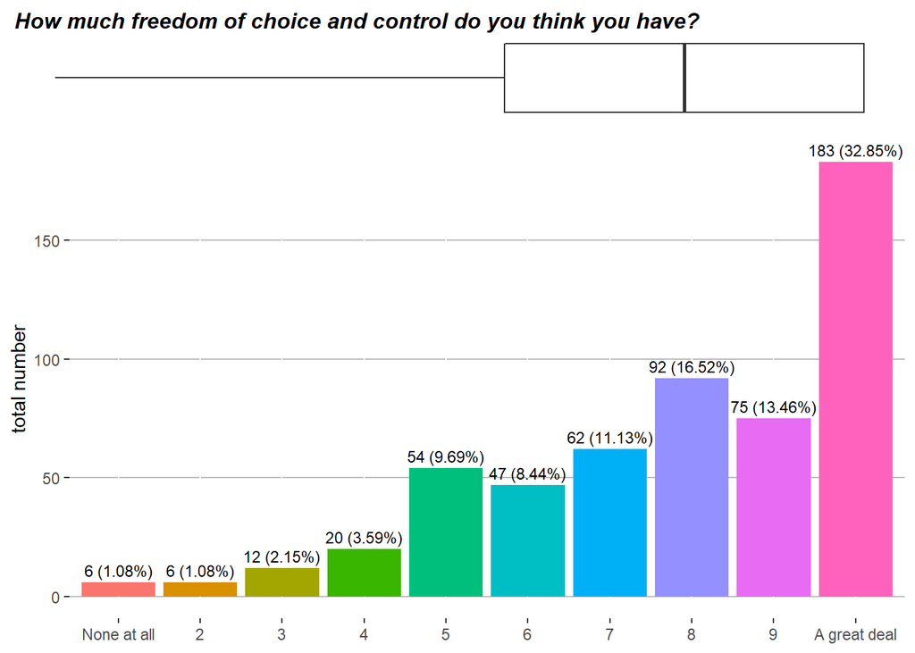

| **id** | **variable** |
| --- | --- |
| 1-4 | not much |
| 5-7 | a little |
| 8-9 | rather agree |
| 10 | A great deal |

This leaves us with the following distribution:

```
##     1) not much     2) a little 3) rather agree 4) a great deal
##              44             163             167             183
```

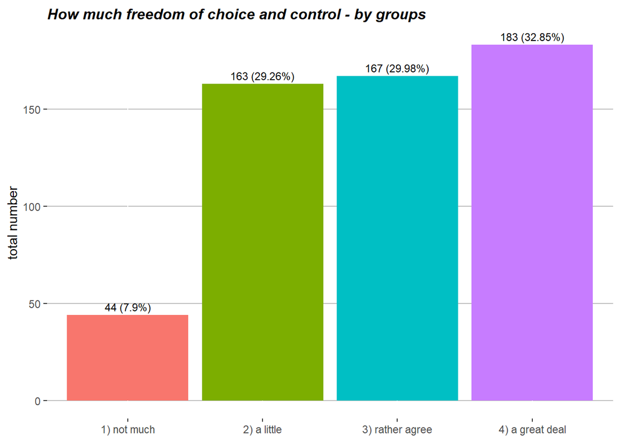

Looking at this distribution, we can observe that most of the respondents seem to feel at least a little in control of how their lives turn out. This is something we need to keep in mind when looking at the correlations between this feeling of control and our dependent variables.

Let us now look if we can find some associations between life satisfaction or happiness in life together with the perceived control that citizens feel they have in their lives.

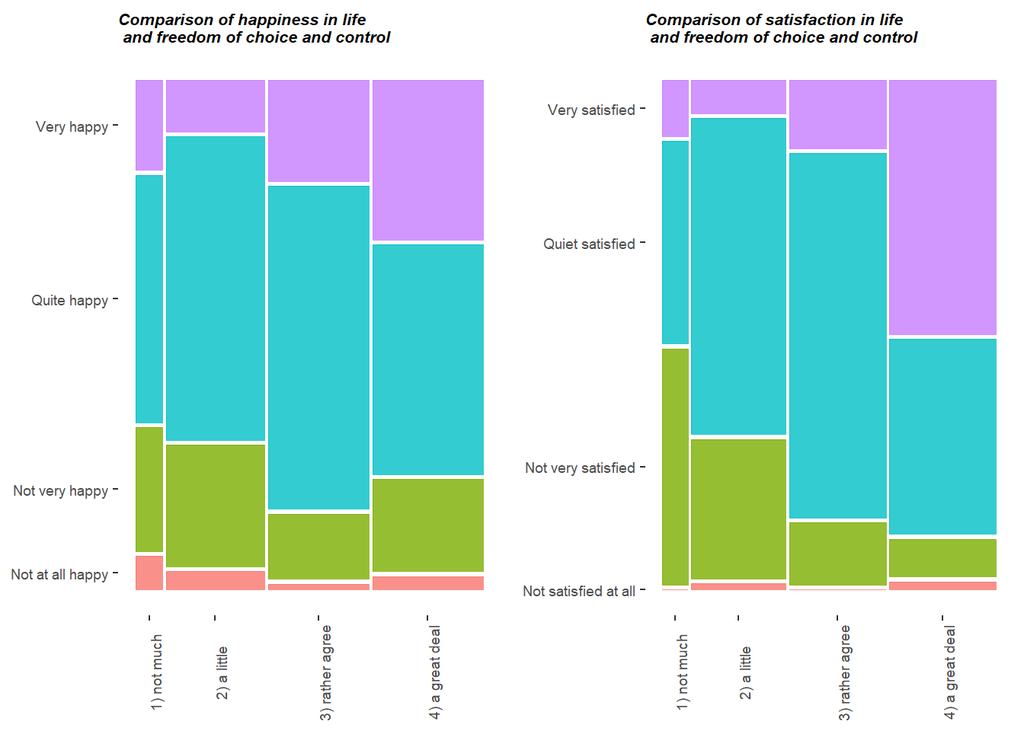

From looking at the mosaic plot, showing the relation between perceived freedom and happiness, a trend that we can observe is that the more people feel in control of their lives, the happier they tend to be. As previously mentioned we need to keep in mind that for those who feel not so much in control of their lives (group 1) we have a rather small sample size. This could be the reason why the trend that we can observe in groups 2 and 3 is not so much reflected in group 1. Looking at group 4 in particular, the trend also seems to be interrupted. However we can observe a higher percentage of respondents who feel like they have a lot of influence on their lives who also claim to be very happy as compared to groups 2 or 3.

Analyzing the right graph which compares satisfaction in life to freedom of choice and control, we notice a much clearer trend across the board. We could generally say that the more the Romanian people feel in control of their lives, the more satisfied they were. It needs to be noted, that especially in the group that feels not so much in control (group 1) we are working with a rather small sample size. However, this does not diminish the trend otherwise observed in the dataset and leads us to the conclusion that we will consider this variable further.

# 8 Additional Variable: Marital Status subject to Gender

The variable we have chosen for this exercise is the one of marital status subject to the gender of a given respondent. The reason for this is, that the way a respondent lives at home (in a partnership or by oneself) is an important indicator of their lifestyle and can be expected to influence their happiness or satisfaction to a certain extent. However, there are limitations to this variable. We have recoded the original data and grouped the responses for marital status into two broad categories: Living in a partnership or by oneself. The original data does not contain a response for non-official partnerships which would be an interesting information to have. Furthermore we cannot tell from this data how much value a given respondent places on their partnership. Nonetheless, the following barplot displays the distribution of marital status subject to gender of a respondent.

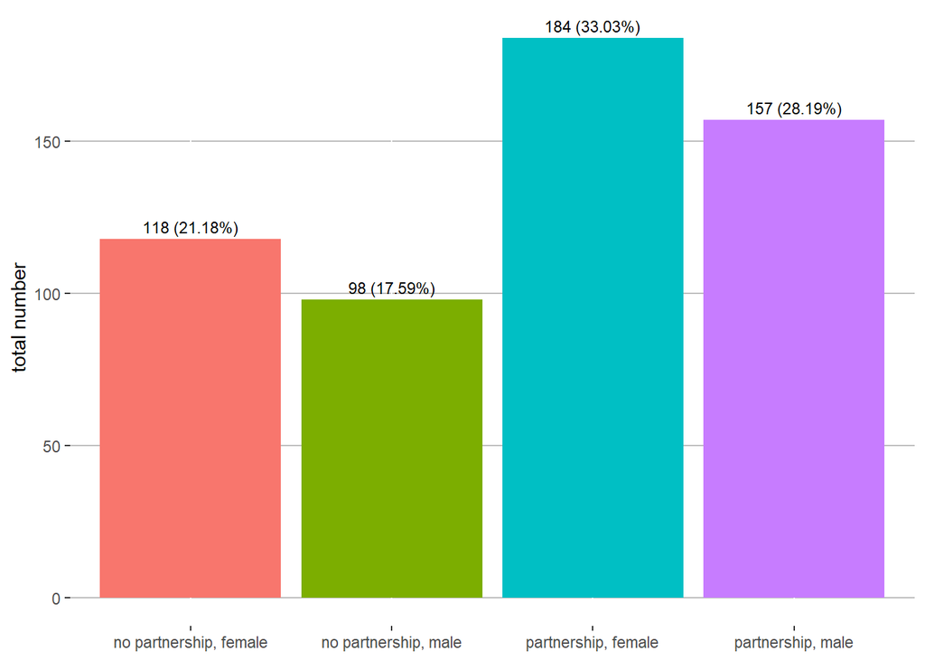

We can see, that generally there are more people in our dataset that live in a relationship. This is true for male and female respondents alike. However,the distribution is not too asymmetrical, which is why the following plots will examine the impact of marital status on happiness and satisfaction.

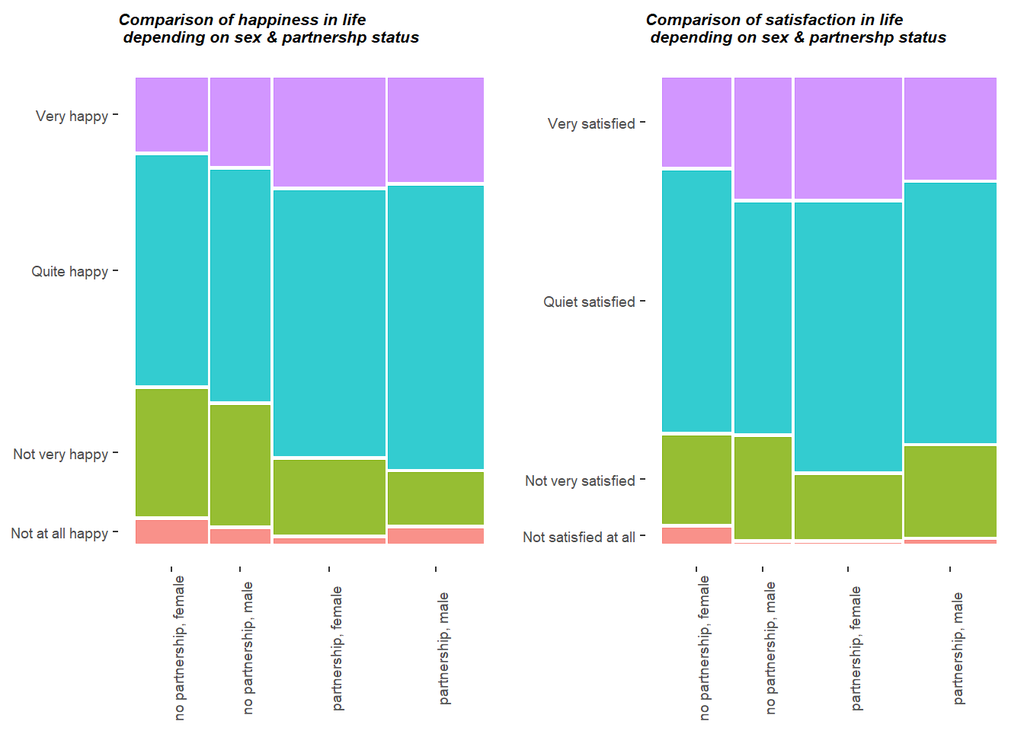

Starting with happiness in life, we can observe a slight increase in the frequency of responses for “quite” or “very” happy. The main difference seems to be between the two groups “partnership” and “no partnership”. The difference between the two genders is rather small. The main increase happens in the percentage of respondents claiming to be “quite happy” with their situation.

For satisfaction, the picture is a lot less clear. It is almost impossible to observe a trend within the plot, as for instance as for instance the female respondents without a partnership seem to behave rather similarly as the male respondents living in a partnership.

Since we would expect that marital status has a uniform effect on happiness or satisfaction and the effect on happiness mentioned earlier is not overwhelmingly large, we decided to not include this variable in further analysis.